# Exercício - Econometria

## **Resolução**

Inicialmente vamos carregar os dados e verificar se a importação teve sucesso.

```r
wine <- read.table("wine.txt", header = T)
print(wine)
```

```
##    claridade aroma corpo sabor aromac qualidade regiao
## 1        1.0   3.3   2.8   3.1    4.1       9.8      1
## 2        1.0   4.4   4.9   3.5    3.9      12.6      1
## 3        1.0   3.9   5.3   4.8    4.7      11.9      1
## 4        1.0   3.9   2.6   3.1    3.6      11.1      1
## 5        1.0   5.6   5.1   5.5    5.1      13.3      1
## 6        1.0   4.6   4.7   5.0    4.1      12.8      1
## 7        1.0   4.8   4.8   4.8    3.3      12.8      1
## 8        1.0   5.3   4.5   4.3    5.2      12.0      1
## 9        1.0   4.3   4.3   3.9    2.9      13.6      3
## 10       1.0   4.3   3.9   4.7    3.9      13.9      1
## 11       1.0   5.1   4.3   4.5    3.6      14.4      3
## 12       0.5   3.3   5.4   4.3    3.6      12.3      2
## 13       0.8   5.9   5.7   7.0    4.1      16.1      3
## 14       0.7   7.7   6.6   6.7    3.7      16.1      3
```

[output cut: 24 more lines]

A importação está correta. Em seguida, fatorizamos a variável `regiao`:

```r
wine$regiao <- factor(wine$regiao)
```

Analisando agora o diagrama de dispersão das variáveis contínuas, temos:

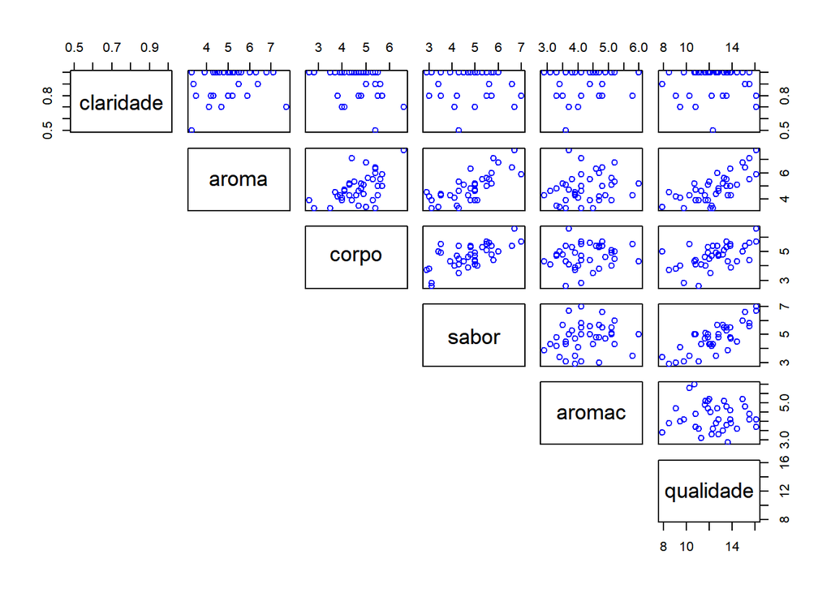

```r
## Para simplificar a visualização, podemos omitir a parte inferior
## (ou superior) da matriz de gráficos de dispersão, pois os gráficos
## são simétricos.

pairs(wine[, -7], lower.panel = NULL, col = "blue")
```

há uma clara correlação positiva forte entre a qualidade do vinho e suas características, em particular o aroma (do vinho e não do tonel de carvalho), o corpo e o sabor. Por outro lado, a claridade não parece se relacionar com nenhuma das demais variáveis; além disso, aroma e corpo são correlacionados positivamnete com o sabor.

Para verificar de forma mais robusta a existência de correlação, vamos calcular as correlações lineares de Pearson entre as variáveis contínuas. Para isso podemos utilizar a função `ggpairs` do pacote `GGally`:

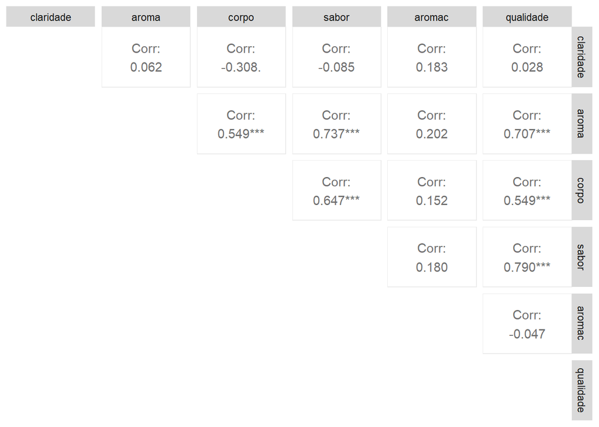

```r
ggpairs(wine[, -7], lower = NULL, diag = NULL)
```

Verificamos que todas as correlações significativas são positivas. Em particular, há uma correlação muito elevada entre o `sabor` e a `qualidade` dos vinhos (0.790); entre o `sabor` e o `aroma` (0.737) e entre o `aroma` e a `qualidade` (0.707). As demais variáveis correlacionadas são `corpo` com `aroma`, `qualidade` e `sabor`. Cabe destacar ainda que a significância estatística das correlações discutidas é ao nível de 1$\%.$.

Analisando agora os `boxplots`, temos:

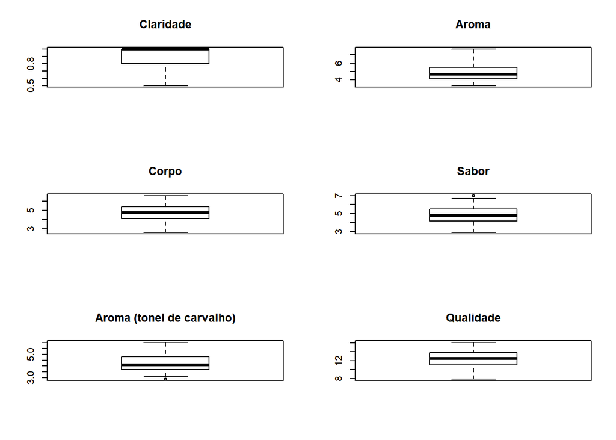

```r
attach(wine)

par(mfrow = c(3, 2)) # Comando para criar uma matriz de gráficos

adjbox(claridade, main = "Claridade")
adjbox(aroma, main = "Aroma")
adjbox(corpo, main = "Corpo")
adjbox(sabor, main = "Sabor")
adjbox(aromac, main = "Aroma (tonel de carvalho)")
adjbox(qualidade, main = "Qualidade")
```

```r
par(mfrow = c(1, 1)) # Voltando para o padrão
```

a maioria das variáveis apresenta uma distribuição razoavelmente simétrica e sem valores extremos. As exceções são `claridade` e `aroma`, que não possuem simetria e a variável `sabor`, que tem uma observação com valor muito elevado, o que pode afetar as futuras estimações.

Vamos agora estimar o modelo de regressão múltipla visando explicar a qualidade do vinho em função das outras variáveis.

```r
reg_inicial <- lm(qualidade ~ ., data = wine) # A fórmula `qualidade ~ .`
                                              # quer dizer "qualidade em
                                              # função de todas as outras
                                              # variáveis.

summary(reg_inicial)
```

```
##
## Call:
## lm(formula = qualidade ~ ., data = wine)
##
## Residuals:
##      Min       1Q   Median       3Q      Max
## -1.80824 -0.58413 -0.02081  0.48627  1.70909
##
## Coefficients:
##             Estimate Std. Error t value Pr(>|t|)
## (Intercept)  7.81437    1.96944   3.968 0.000417 ***
## claridade    0.01705    1.45627   0.012 0.990736
## aroma        0.08901    0.25250   0.353 0.726908
## corpo        0.07967    0.26772   0.298 0.768062
## sabor        1.11723    0.24026   4.650 6.25e-05 ***
## aromac      -0.34644    0.23301  -1.487 0.147503
## regiao2     -1.51285    0.39227  -3.857 0.000565 ***
## regiao3      0.97259    0.51017   1.906 0.066218 .
## ---
## Signif. codes:  0 '***' 0.001 '**' 0.01 '*' 0.05 '.' 0.1 ' ' 1
##
## Residual standard error: 0.9154 on 30 degrees of freedom
## Multiple R-squared:  0.8376, Adjusted R-squared:  0.7997
## F-statistic:  22.1 on 7 and 30 DF,  p-value: 3.295e-10
```

Como podemos ver, há diversas variáveis que não atingiram significância estatística. Antes de realizarmos a interpretação do modelo, é interessante removermos essas variáveis e verificarmos se o ajuste do modelo (medido pelo R$^2$ ajustado) varia significativamente.

```r
reg_final <- lm(qualidade ~ sabor + regiao, data = wine)

summary(reg_final)
```

```
##
## Call:
## lm(formula = qualidade ~ sabor + regiao, data = wine)
##
## Residuals:
##      Min       1Q   Median       3Q      Max
## -1.97630 -0.58844  0.02184  0.51572  1.94232
##
## Coefficients:
##             Estimate Std. Error t value Pr(>|t|)
## (Intercept)   7.0943     0.7912   8.967 1.76e-10 ***
## sabor         1.1155     0.1738   6.417 2.49e-07 ***
## regiao2      -1.5335     0.3688  -4.158 0.000205 ***
## regiao3       1.2234     0.4003   3.056 0.004346 **
## ---
## Signif. codes:  0 '***' 0.001 '**' 0.01 '*' 0.05 '.' 0.1 ' ' 1
##
## Residual standard error: 0.8946 on 34 degrees of freedom
## Multiple R-squared:  0.8242, Adjusted R-squared:  0.8087
## F-statistic: 53.13 on 3 and 34 DF,  p-value: 6.358e-13
```

Para analisar os resíduos do modelo estimado, inicialmente vamos checar a sua normalidade utilizando um gráfico Q-Q. Temos:

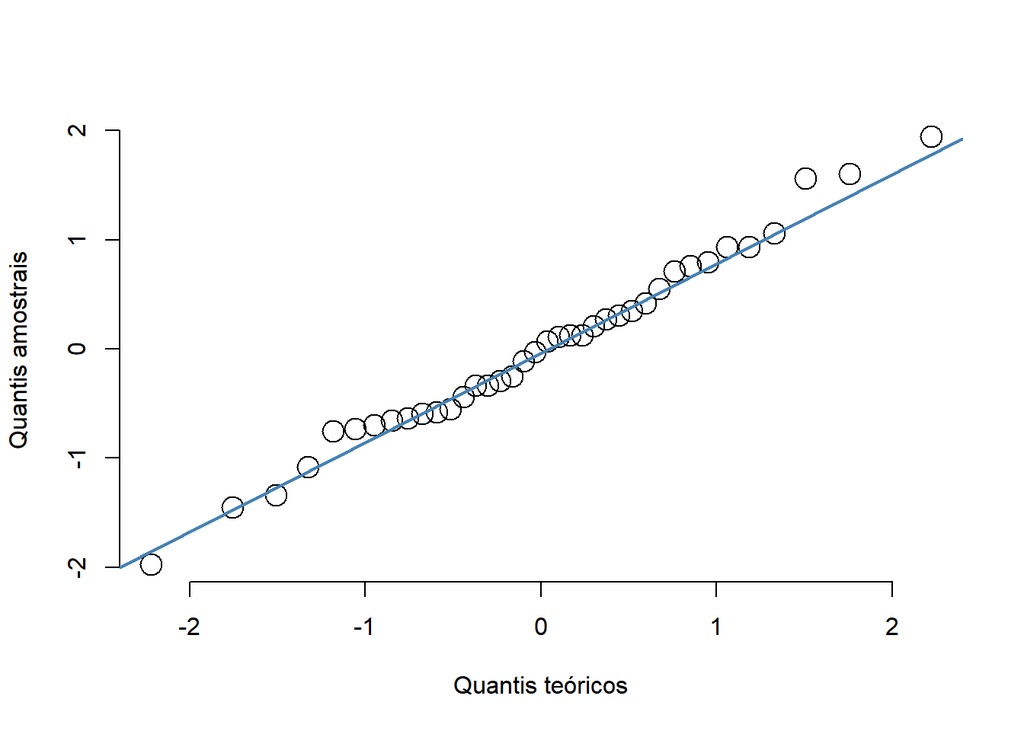

```r
qqnorm(reg_final$residuals, pch = 1, frame = FALSE, cex = 2,
       xlab = "Quantis teóricos", ylab = "Quantis amostrais",
       main = "")
qqline(reg_final$residuals, col = "steelblue", lwd = 2)
```

veja que os resíduos aparentam ser normalmente distribuídos, com exceção de alguns pontos mais extremos. De fato, realizando o teste de Shapiro-Wilk para normalidade, temos:

```r
shapiro.test(reg_final$residuals)
```

```
##
##  Shapiro-Wilk normality test
##
## data:  reg_final$residuals
## W = 0.98843, p-value = 0.9577
```

como o p-valor é bastante alto, não rejeitamos a hipótese nula de normalidade dos resíduos.

A seguir, iremos analisar a presença de heterogeneidade nos resíduos. Para isso podemos criar um gráfico com os resíduos no eixo y e os valores estimados no eixo x, conforme abaixo:

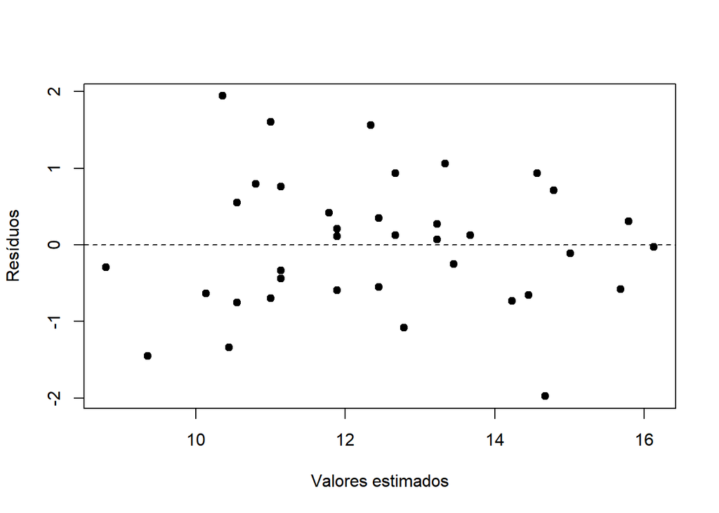

```r
plot(reg_final$residuals ~ reg_final$fitted.values, pch = 19,
     xlab = "Valores estimados", ylab = "Resíduos")
abline(h = 0, lty = 2)
```

uma vez que os pontos se distribuem de maneira simétrica ao redor da linha horizontal $ y = 0 $, não há evidência de heterocedasticidade nos resíduos do modelo. Em seguida, para analisar a hipótese de linearidade do modelo utilizamos um gráfico da variável explicativa contínua `sabor` *versus* os valores da variável dependente. Temos:

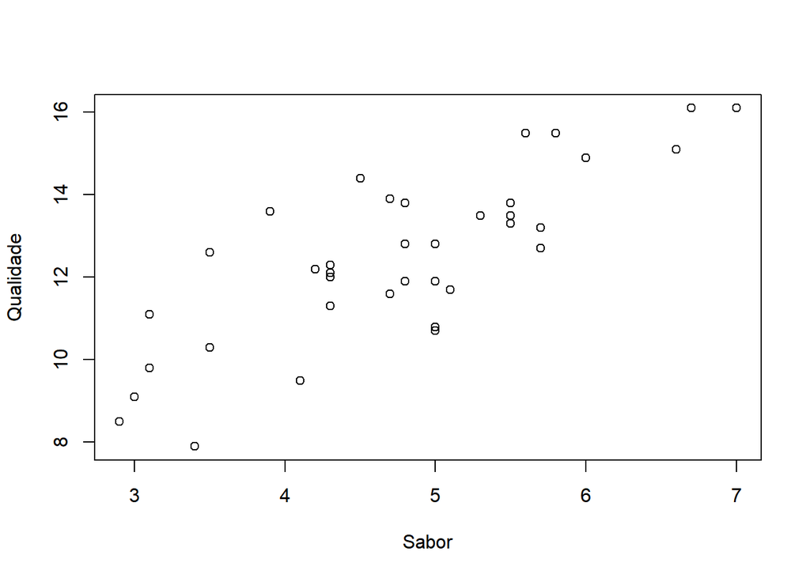

```r
plot(wine$qualidade ~ wine$sabor, xlab = "Sabor", ylab = "Qualidade")
```

uma vez que os pontos não apresentam uma relação não-linear (um exemplo clássico é o formato de parábola), não há preocupação com uma possível violação da hipótese de linearidade do modelo.

Para analisar a questão da multicolinearidade vamos calcular o fator de inflacionamento de variância (VIF); caso para alguma variável esse valor seja superior a 10, há indícios de multicolinearidade prejudicial:

```r
VIF(reg_final)
```

```
##            GVIF Df GVIF^(1/(2*Df))
## sabor  1.476509  1        1.215117
## regiao 1.476509  2        1.102323
```

os resultados obtidos apontam que não há multicolinearidade prejudical no modelo. Por fim, para analisar a presença de observações muito influentes (*outliers*), iremos calcular as distâncias de Cook para o modelo estimado. Para tanto vamos utilizar a função `ols_plot_cooksd_bar` do pacote `olsrr`:

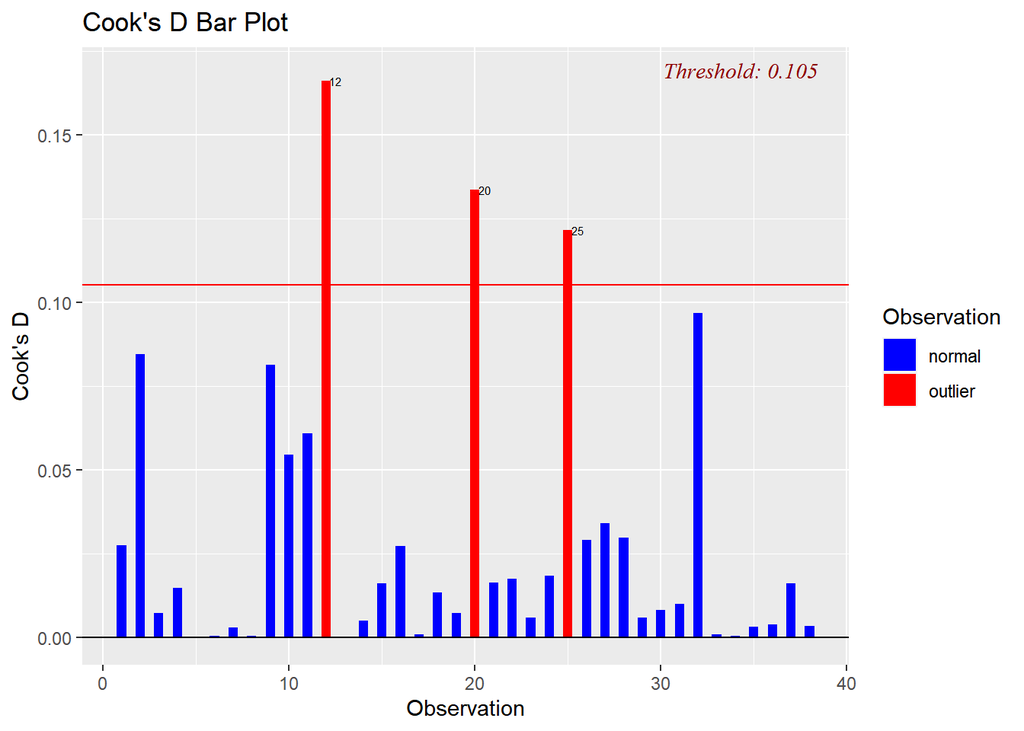

```r
ols_plot_cooksd_bar(reg_final)
```

podemos notar que as observações `12, 20` e `25` são muito influenciais. Assim, vamos comparar os modelos com e sem elas para ver se há muitas diferenças:

```r
reg_sem_influentes <- lm(qualidade ~ sabor + regiao,
                         data = wine[-c(12, 20, 25), ])

summary(reg_sem_influentes)
```

```
##
## Call:
## lm(formula = qualidade ~ sabor + regiao, data = wine[-c(12, 20,
##     25), ])
##
## Residuals:
##      Min       1Q   Median       3Q      Max
## -1.39616 -0.55695 -0.08442  0.45480  1.57559
##
## Coefficients:
##             Estimate Std. Error t value Pr(>|t|)
## (Intercept)   7.2699     0.6681  10.882 4.10e-12 ***
## sabor         1.0754     0.1470   7.314 3.12e-08 ***
## regiao2      -1.5972     0.3332  -4.793 3.88e-05 ***
## regiao3       1.4525     0.3390   4.285 0.000165 ***
## ---
## Signif. codes:  0 '***' 0.001 '**' 0.01 '*' 0.05 '.' 0.1 ' ' 1
##
## Residual standard error: 0.7403 on 31 degrees of freedom
## Multiple R-squared:  0.8728, Adjusted R-squared:  0.8605
## F-statistic: 70.89 on 3 and 31 DF,  p-value: 5.634e-14
```

Em seguida, temos a tabela ANOVA do modelo escolhido:

```r
print(anova(reg_sem_influentes))
```

```
## Analysis of Variance Table
##
## Response: qualidade
##           Df Sum Sq Mean Sq F value    Pr(>F)
## sabor      1 83.242  83.242 151.870 1.751e-13 ***
## regiao     2 33.328  16.664  30.402 4.917e-08 ***
## Residuals 31 16.992   0.548
## ---
## Signif. codes:  0 '***' 0.001 '**' 0.01 '*' 0.05 '.' 0.1 ' ' 1
```

Verificamos, portanto, que apenas as variáveis referentes ao sabor do vinho e a região de sua produção são importantes para explicar a qualidade do produto. Quanto melhor o sabor (maior valor), maior a qualidade do vinho, com um aumento de 1 unidade no sabor resultando em uma variação para cima de 1,07 unidade na qualidade. O mesmo é observado para vinhos produzidos na região 3, apresentando uma qualidade 1,45 unidade maior do que os da região 1 (referência). Por outro lado, os produtos da região 2 têm uma qualidade 1,60 unidade mais baixa do que a região 1.